# Protocolo de preparación de datos y análisis exploratorio orientado a hipótesis

Determinantes socioeducativos del rendimiento en lectura y matemática en estudiantes de 6.° grado de primaria del Perú (ENLA 2024). Producto de la Unidad I

Autores/as

María del Pilar Mori Sánchez

Boris Jesús Arce Saavedra

Fecha de publicación

12 de noviembre de 2026

# 1 Contexto y pregunta de investigación

Las brechas de aprendizaje asociadas al lugar de residencia y al tipo de institución educativa (IE) persisten en la educación primaria peruana y condicionan las trayectorias escolares posteriores. Este protocolo documenta la preparación del archivo muestral de la Evaluación Nacional de Logros de Aprendizaje (ENLA) 2024 de 6.° grado de primaria, elaborado por la Oficina de Medición de la Calidad de los Aprendizajes (UMC) del Ministerio de Educación (MINEDU), y el análisis exploratorio que orientará la modelación de la Unidad II.

La pregunta de investigación es la siguiente: ¿de qué manera el área geográfica, la gestión de la IE y el sexo del estudiante se asocian con la medida de logro y con el nivel de logro en lectura y matemática de los estudiantes de 6.° grado evaluados en la ENLA 2024? El alcance declarado en el Avance 1 es explicativo y predictivo. En esta unidad el análisis es descriptivo e inferencial a nivel poblacional; ninguna de las asociaciones reportadas admite lectura causal, porque las tres variables explicativas son atributos no manipulables y el diseño es transversal.

Las hipótesis que orientan el análisis exploratorio son cuatro:

- **H1 (área).** Los estudiantes de IE urbanas obtienen medidas promedio y proporciones de logro satisfactorio mayores que los de IE rurales en ambas pruebas, y la brecha se mantiene dentro de la gestión pública.
- **H2 (gestión).** Los estudiantes de IE privadas superan a los de IE públicas en ambas pruebas.
- **H3 (sexo).** La brecha por sexo cambia de dirección según el área curricular: favorece a las mujeres en lectura y a los hombres en matemática.
- **H4 (anidamiento).** Una proporción sustantiva de la varianza de los puntajes (correlación intraclase > 0,10) se ubica entre IE, lo que exige modelos multinivel o validación agrupada en la Unidad II.

# 2 Fuentes de datos y consideraciones éticas

**Fuente y linaje.** El insumo único es el archivo `BD_6P ENLA muestral 2024.xlsx`, descargado del portal de bases de datos de la UMC y conservado sin modificaciones en `data/raw/`. Contiene tres hojas: `BD` (105 242 registros y 21 variables), `Diccionario de variables` y `Observaciones` (vacía). La unidad de análisis es el estudiante. La muestra incluye 4 442 IE de 26 DRE, distribuidas en 123 estratos muestrales. El linaje completo es: portal UMC → `data/raw/` (solo lectura) → `R/01_preparacion.R` → `data/processed/enla6p_2024_curado.rds|csv` → este reporte. La integración de fuentes en esta unidad se limitó a incorporar el diccionario oficial de la hoja `Diccionario de variables` como etiquetas de los factores y a derivar variables contextuales de IE y sección a partir de la propia base.

**Diseño muestral.** La ENLA 2024 de 6.° grado es una evaluación muestral. Cada registro trae un factor de expansión propio para cada prueba (`peso_Lectura`, `peso_Mate`), que difiere entre pruebas en 41 431 casos. Todas las estimaciones de este reporte usan el diseño complejo (conglomerado: IE; estrato: `Estrato_DRE`; peso de la prueba correspondiente) con el paquete *survey* (Lumley, 2004). Los valores sin ponderar se usan solo para describir la base.

**Ética y datos sensibles.** Se trata de un análisis secundario de datos administrativos anonimizados por el MINEDU, por lo que no corresponde recabar consentimiento informado adicional. La base no contiene nombres, DNI ni códigos modulares; `ID_IE` es un código anonimizado y `cor_est` un correlativo dentro de la sección. El dataset curado sustituye `cor_est` por un identificador compuesto y no incorpora información personal identificable. Los resultados se reportan siempre de forma agregada. Los términos de uso de la base deben verificarse en el portal de la UMC antes de redistribuir el archivo crudo; el código del repositorio puede publicarse bajo licencia MIT, en coherencia con el diagnóstico FAIR del Avance 1.

# 3 Limpieza e integración

El script `R/01_preparacion.R` se ejecuta de inicio a fin sin intervención manual y se detiene si alguna verificación de integridad falla. La Tabla 1 resume el diagnóstico de calidad y la Tabla 2 registra cada decisión con su justificación, la alternativa descartada y su efecto sobre el número de casos o variables; las cifras de ambas tablas se calculan por código.

**Ver código**

```r
nf <- function(x) sum(is.na(x))
calidad <- data.frame(
  Aspecto = c("Registros / variables", "Duplicados (clave y fila completa)",
              "Faltantes en medida y nivel de Lectura", "Faltantes en medida y nivel de Matemática",
              "Faltantes en ambas pruebas", "Faltantes en variables contextuales",
              "Valores extremos |z| > 3 (Lectura / Matemática)",
              "Coherencia nivel–medida", "IE con más de una gestión o área"),
  Resultado = c(paste(f0(n_tot), "/ 21"), "0 / 0",
                paste0(f0(nf(d$lect)), " (", pc(mean(is.na(d$lect))), ")"),
                paste0(f0(nf(d$mat)), " (", pc(mean(is.na(d$mat))), ")"),
                f0(sum(is.na(d$lect) & is.na(d$mat))), "0 en las 14 variables",
                paste(sum(d$atip_lect, na.rm = TRUE), "/", sum(d$atip_mat, na.rm = TRUE)),
                "Intervalos sin solapamiento en ambas pruebas", "0")
)
kable(calidad)
```

Tabla 1: Diagnóstico de calidad de la base cruda

| Aspecto | Resultado |
| --- | --- |
| Registros / variables | 105 242 / 21 |
| Duplicados (clave y fila completa) | 0 / 0 |
| Faltantes en medida y nivel de Lectura | 2 576 (2,4 %) |
| Faltantes en medida y nivel de Matemática | 1 720 (1,6 %) |
| Faltantes en ambas pruebas | 0 |
| Faltantes en variables contextuales | 0 en las 14 variables |
| Valores extremos \|z\| > 3 (Lectura / Matemática) | 371 / 927 |
| Coherencia nivel–medida | Intervalos sin solapamiento en ambas pruebas |
| IE con más de una gestión o área | 0 |

**Datos faltantes.** La ausencia de puntaje coincide exactamente con la ausencia del factor de expansión de esa prueba y ningún estudiante carece de ambas, lo que indica que el faltante corresponde a estudiantes no evaluados en una de las dos sesiones. Las tasas de faltantes varían poco entre subgrupos: en lectura oscilan entre 2,1 % y 2,9 % según la combinación gestión-área, y en matemática entre 1,2 % y 2,3 %. Como los puntajes son las variables respuesta, no se imputaron. Este tratamiento supone que, condicionada al diseño y a los pesos, la ausencia es ignorable; el supuesto no puede verificarse con la información disponible y se declara como limitación.

**Valores atípicos.** Las medidas proceden de un modelo de teoría de respuesta al ítem y todos los valores están dentro del rango de la escala. Se conservaron y se marcaron con `atip_lect` y `atip_mat`, porque los valores bajos extremos se concentran en contextos vulnerables y su exclusión reduciría artificialmente las brechas que se busca estimar.

**Ver código**

```r
kable(dec |> dplyr::select(ID = id, Etapa = etapa, `Decisión` = decision,
                           `Justificación` = justificacion,
                           `Alternativa descartada` = alternativa_descartada, Efecto = efecto))
```

Tabla 2: Registro de decisiones de limpieza e ingeniería de variables

| ID | Etapa | Decisión | Justificación | Alternativa descartada | Efecto |
| --- | --- | --- | --- | --- | --- |
| D01 | Gobernanza | Conservar el Excel original en data/raw/ sin modificaciones; todo cambio se aplica por código | Trazabilidad y reproducibilidad: el crudo es la referencia para auditar cualquier transformación | Editar o filtrar directamente el Excel | Crudo intacto: 105242 filas x 21 columnas |
| D02 | Integridad | Construir id_est = ID_IE_ID_SECCION_cor_est y verificar unicidad | La base no trae identificador único de estudiante; la combinación de los tres campos lo es por construcción | Deduplicar por coincidencia de todas las columnas | 0 duplicados por clave y 0 filas duplicadas; n = 105242 |
| D03 | Integridad | Verificar coherencia interna: códigos válidos, una gestión y un área por IE, niveles de logro sin solapamiento con la medida, peso faltante solo cuando falta el puntaje | Detectar errores de digitación o de fusión antes de modelar; el script se detiene si alguna verificación falla | Confiar en la estructura del archivo sin verificar | Todas las verificaciones superadas; 0 IE inconsistentes |
| D04 | Faltantes | No imputar lect (2,4 % faltante) ni mat (1,6 % faltante); crear falta_lect y falta_mat; analizar cada área con sus casos disponibles | Los puntajes son variables respuesta; el faltante coincide exactamente con la ausencia de peso, lo que indica estudiante no evaluado en esa prueba. Imputar la respuesta crearía información artificial … | Eliminación por lista en ambas pruebas (n pasaría de 105242 a 100946) o imputación múltiple de la respuesta | n total = 105242; n analítico lectura = 102666; matemática = 103522; ambas = 100946 |
| D05 | Atípicos | Conservar los valores extremos (\|z\| > 3: 371 en lectura, 927 en matemática) y marcarlos con atip_lect y atip_mat | Las medidas provienen de un modelo TRI y son valores plausibles de la escala; los extremos bajos se concentran en contextos vulnerables, de modo que eliminarlos sesgaría las brechas | Eliminar o winsorizar los 371 + 927 casos extremos | 0 casos eliminados; 2 indicadores nuevos |
| D06 | Codificación | Recodificar gestion2, area y sexo a factores etiquetados según el diccionario del MINEDU | Evitar que R trate códigos nominales como cantidades y documentar las etiquetas oficiales | Mantener códigos numéricos 1/2 | 3 variables recodificadas; sin cambio en n |
| D07 | Codificación | Convertir los niveles de logro a factor ordenado y derivar satisf_lect, satisf_mat y satisf_ambas | El nivel de logro es la métrica de política educativa; la binaria satisfactorio/no permite plantear una tarea de clasificación en la Unidad II | Usar solo la medida continua | 2 factores ordenados y 3 binarias nuevas |
| D08 | Variables derivadas | Crear gestion_area (4 categorías); la celda Privada-Rural tiene n = 381 | Gestión y área están asociadas; la combinación permite examinar el confusor y advierte sobre una celda escasa | Analizar gestión y área únicamente por separado | 1 variable nueva |
| D09 | Variables derivadas | Crear n_eval_ie y n_eval_seccion como variables contextuales de tamaño | El número de evaluados aproxima el tamaño de la IE sin usar resultados de aprendizaje | Media de la IE en lectura o matemática (descartada por fuga de información) | 2 variables nuevas |
| D10 | Escalamiento | Estandarizar lect y mat (z_lect, z_mat) con la media y DE de la muestra completa, solo para el EDA | Facilitar comparaciones en unidades de DE y la detección de atípicos | Estandarizar con parámetros fijos de la escala oficial (no publicados en la base) | 2 variables nuevas; deben reajustarse dentro de la validación cruzada en la Unidad II |
| D11 | Diseño muestral | Estimar descriptivos con el diseño complejo: conglomerado id_ie, estrato Estrato_DRE y peso específico de cada prueba; los estratos con una sola IE (1) se tratan con survey.lonely.psu = ‘adjust’ | ENLA 2024 es una muestra estratificada por conglomerados con probabilidades desiguales; las medias sin ponderar no representan a la población de 6.° grado | Estadísticos sin ponderar y errores estándar que asumen muestreo aleatorio simple | Estimaciones representativas con IC 95 % de diseño; sin cambio en n |
| D12 | Selección/reducción | No aplicar Boruta, RFE ni PCA/t-SNE/UMAP en esta unidad | Solo existen cuatro predictores contextuales (gestión, área, sexo, DRE); la selección automática no aporta y una PCA sobre lect y mat mezclaría variables respuesta | Boruta/RFE sobre las cuatro variables o un índice compuesto lect-mat por PCA | Sin cambio en el número de variables |
| D13 | Privacidad | Excluir cor_est del dataset curado (reemplazado por id_est) y no incorporar nombres, DNI ni códigos modulares | Minimización de datos personales; los identificadores de IE ya vienen anonimizados por el MINEDU | Conservar cor_est como variable | Dataset curado: 105242 filas x 33 columnas |

# 4 Ingeniería de características

La codificación convirtió `gestion2`, `area` y `sexo` en factores etiquetados y los niveles de logro en factores ordenados de cuatro categorías. Como variables derivadas se crearon `satisf_lect`, `satisf_mat` y `satisf_ambas` (logro satisfactorio), `gestion_area` (cruce de gestión y área), `n_eval_ie` y `n_eval_seccion` (tamaño de la IE y de la sección en la muestra) y los indicadores `falta_*` y `atip_*`. El escalamiento produjo `z_lect` y `z_mat`, estandarizadas con la media y la desviación estándar de toda la muestra disponible; su uso queda restringido a este análisis exploratorio. El código `codgeo` se formateó como `ubigeo` de seis dígitos para permitir, en la Unidad II, el enlace con indicadores distritales del INEI. El dataset curado tiene 105 242 filas y 33 variables, todas documentadas en el diccionario de datos (`docs/diccionario_datos.xlsx`, Tabla 3).

No se aplicaron Boruta, RFE ni técnicas de reducción de dimensionalidad. El conjunto de predictores disponibles se reduce a gestión, área, sexo y DRE, de modo que la selección automática no tiene espacio de búsqueda, y una PCA sobre `lect` y `mat` construiría un índice a partir de las dos variables respuesta (correlación de Pearson = 0,69), lo que contaminaría cualquier modelo posterior.

**Ver código**

```r
kable(dic |> filter(grepl("Derivada", fuente_origen)) |>
        dplyr::select(Variable = variable, `Descripción` = descripcion, Tipo = tipo,
                      `Valores válidos` = valores_validos))
```

Tabla 3: Extracto del diccionario de datos (variables derivadas)

| Variable | Descripción | Tipo | Valores válidos |
| --- | --- | --- | --- |
| gestion_area | Combinación de gestión y área | factor | Pública-Urbana; Pública-Rural; Privada-Urbana; Privada-Rural |
| n_eval_ie | Número de estudiantes evaluados de la IE en la muestra | entero | 1 a 85 |
| n_eval_seccion | Número de estudiantes evaluados de la sección en la muestra | entero | 1 a 43 |
| satisf_lect | Logro satisfactorio en Lectura | entero | 0 = no; 1 = sí; NA = no evaluado |
| falta_lect | Indicador de puntaje de Lectura faltante | entero | 0 = observado; 1 = faltante |
| z_lect | Medida de Lectura estandarizada | numérico | -5.124 a 3.190 |
| atip_lect | Indicador de valor atípico en Lectura | entero | 0; 1; NA |
| satisf_mat | Logro satisfactorio en Matemática | entero | 0 = no; 1 = sí; NA = no evaluado |
| falta_mat | Indicador de puntaje de Matemática faltante | entero | 0 = observado; 1 = faltante |
| z_mat | Medida de Matemática estandarizada | numérico | -4.416 a 4.280 |
| atip_mat | Indicador de valor atípico en Matemática | entero | 0; 1; NA |
| satisf_ambas | Logro satisfactorio simultáneo en ambas áreas | entero | 0; 1; NA si falta alguna prueba |

# 5 Análisis exploratorio orientado a hipótesis

En la población representada, la medida promedio ponderada fue 528,9 puntos en lectura (DE = 83,2) y 514,3 en matemática (DE = 93,4). El 24,9 % de los estudiantes alcanzó el nivel satisfactorio en lectura y el 13,7 % en matemática. Con más de cien mil casos, prácticamente cualquier diferencia es estadísticamente significativa, por lo que la interpretación se apoya en la magnitud de la diferencia, su intervalo de confianza de diseño y la *d* de Cohen, calculada como la diferencia de medias dividida por la DE poblacional ponderada de cada prueba (Cohen, 1988).

## 5.1 H1. Brecha urbano-rural

**Ver código**

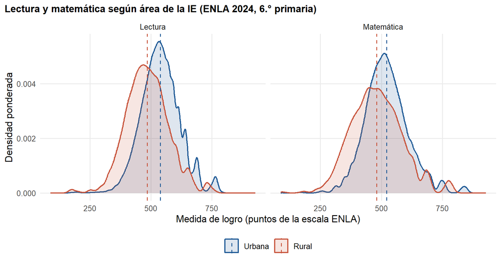

Figura 1: Distribución ponderada de las medidas de logro por área. Las líneas discontinuas indican la media ponderada.

```r
fig_densidad("area", "Lectura y matemática según área de la IE (ENLA 2024, 6.° primaria)")
```

**Ver código**

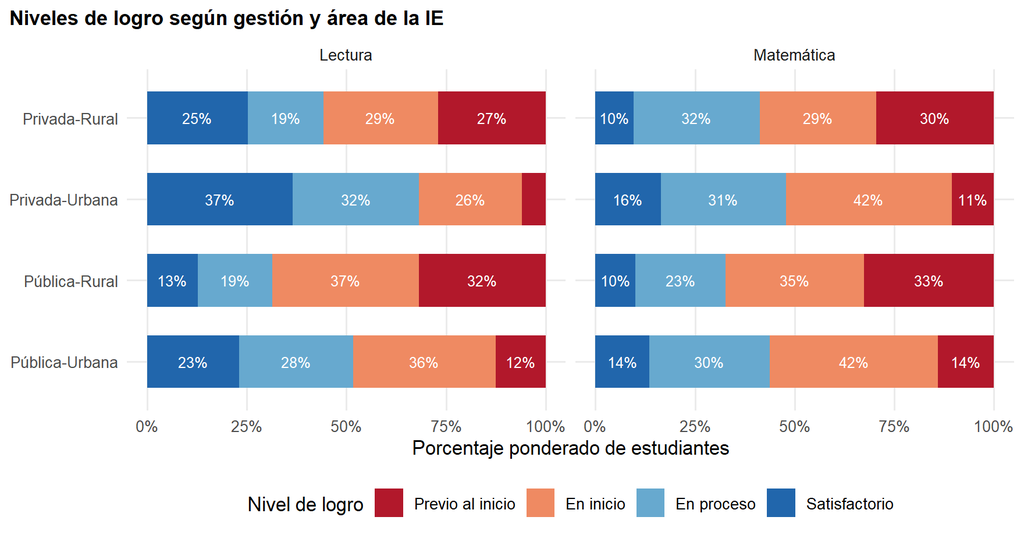

Figura 2: Distribución ponderada de los niveles de logro por combinación de gestión y área de la IE.

```r
fig_niveles("gestion_area", "Niveles de logro según gestión y área de la IE")
```

**Ver código**

```r
kable(tab_contraste(cA))
```

Tabla 4: Medias ponderadas por área, diferencia Rural − Urbana y tamaño del efecto

| Prueba | Grupo | Media (IC 95 %) | Diferencia (IC 95 %) | d (IC 95 %) |
| --- | --- | --- | --- | --- |
| Lectura | Urbana | 538,5 (536,5; 540,5) | -53,5 (-57,5; -49,6) | -0,64 (-0,69; -0,60) |
| Lectura | Rural | 484,9 (481,6; 488,3) |  |  |
| Matemática | Urbana | 521,7 (519,2; 524,1) | -41,0 (-45,4; -36,7) | -0,44 (-0,49; -0,39) |
| Matemática | Rural | 480,6 (477,1; 484,2) |  |  |

La distribución rural se desplaza hacia la izquierda en ambas pruebas (Figura 1). La diferencia Rural − Urbana fue de -53,5 puntos en lectura (*d* = -0,64) y de -41,0 en matemática (*d* = -0,44) (Tabla 4). El logro satisfactorio en lectura fue 27,4 % en zonas urbanas frente a 13,2 % en zonas rurales; en matemática, 14,4 % frente a 10,1 %. Como el 98,5 % de los estudiantes rurales de la muestra asiste a IE públicas, la brecha bruta podría reflejar en parte la composición por gestión. Restringida a la gestión pública, la diferencia se mantiene en -44,8 puntos en lectura (IC 95 %: -48,8; -40,7) y -37,9 en matemática (IC 95 %: -42,2; -33,5).

**Conclusión provisional: la evidencia apoya H1.** La brecha es de magnitud media en lectura y entre pequeña y media en matemática, y persiste dentro de la gestión pública.

## 5.2 H2. Gestión pública y privada

**Ver código**

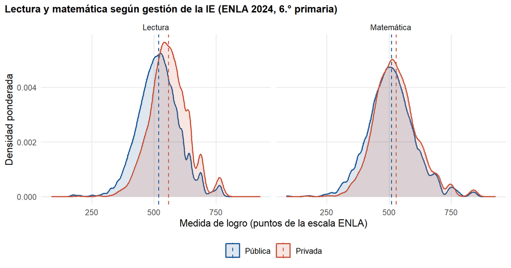

Figura 3: Distribución ponderada de las medidas de logro por gestión de la IE.

```r
fig_densidad("gestion", "Lectura y matemática según gestión de la IE (ENLA 2024, 6.° primaria)")
```

**Ver código**

```r
kable(tab_contraste(cG))
```

Tabla 5: Medias ponderadas por gestión, diferencia Privada − Pública y tamaño del efecto

| Prueba | Grupo | Media (IC 95 %) | Diferencia (IC 95 %) | d (IC 95 %) |
| --- | --- | --- | --- | --- |
| Lectura | Pública | 518,3 (516,7; 519,9) | 39,9 (34,9; 45,0) | 0,48 (0,42; 0,54) |
| Lectura | Privada | 558,3 (553,5; 563,0) |  |  |
| Matemática | Pública | 509,3 (507,3; 511,3) | 18,9 (12,7; 25,2) | 0,20 (0,14; 0,27) |
| Matemática | Privada | 528,2 (522,3; 534,2) |  |  |

La ventaja de la gestión privada fue de 39,9 puntos en lectura (*d* = 0,48) y de 18,9 en matemática (*d* = 0,20) (Tabla 5, Figura 3). La asimetría entre pruebas es clara: el logro satisfactorio en lectura pasa de 20,7 % a 36,4 %, mientras que en matemática solo pasa de 12,7 % a 16,3 %. Dentro del área urbana, donde se concentra la oferta privada, la diferencia se reduce a 30,4 puntos en lectura (IC 95 %: 25,2; 35,6) y 10,8 en matemática (IC 95 %: 4,4; 17,3). La celda Privada-Rural (n = 381) produce estimaciones imprecisas (Figura 2) y no permite contrastar la gestión dentro del área rural.

**Conclusión provisional: la evidencia apoya H2 en lectura y la apoya de forma débil en matemática.** La base no contiene el nivel socioeconómico de las familias, que es el confusor más plausible de la ventaja privada; sin esa variable, la diferencia no puede atribuirse a la gestión.

## 5.3 H3. Brecha por sexo según el área curricular

**Ver código**

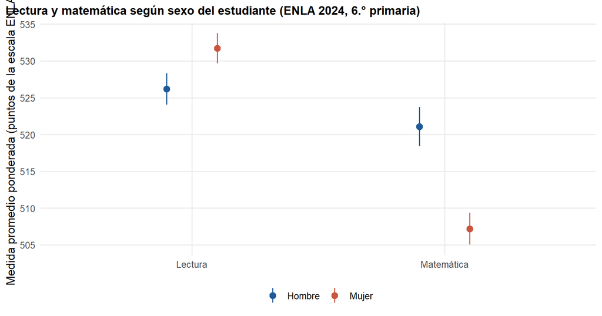

Figura 4: Media ponderada e IC 95 % de diseño por sexo en cada prueba.

```r
cS |>
  ggplot(aes(x = prueba, y = media, colour = grupo)) +
  geom_pointrange(aes(ymin = li, ymax = ls), position = position_dodge(width = 0.4), size = 0.5) +
  scale_colour_manual(values = pal2, name = NULL) +
  labs(title = "Lectura y matemática según sexo del estudiante (ENLA 2024, 6.° primaria)",
       x = NULL, y = "Medida promedio ponderada (puntos de la escala ENLA)") + tema
```

**Ver código**

```r
kable(tab_contraste(cS))
```

Tabla 6: Medias ponderadas por sexo, diferencia Mujer − Hombre y tamaño del efecto

| Prueba | Grupo | Media (IC 95 %) | Diferencia (IC 95 %) | d (IC 95 %) |
| --- | --- | --- | --- | --- |
| Lectura | Hombre | 526,2 (524,1; 528,3) | 5,5 (3,2; 7,9) | 0,07 (0,04; 0,09) |
| Lectura | Mujer | 531,7 (529,7; 533,8) |  |  |
| Matemática | Hombre | 521,1 (518,4; 523,7) | -13,9 (-16,2; -11,5) | -0,15 (-0,17; -0,12) |
| Matemática | Mujer | 507,2 (505,0; 509,4) |  |  |

Las mujeres superaron a los hombres en lectura por 5,5 puntos (*d* = 0,07), y los hombres superaron a las mujeres en matemática por 13,9 puntos (*d* = -0,15) (Tabla 6, Figura 4). En matemática, la proporción de logro satisfactorio fue 16,2 % en hombres y 11,0 % en mujeres.

**Conclusión provisional: la evidencia apoya H3 en cuanto a la dirección de las brechas.** Ambos efectos son pequeños, sobre todo en lectura, donde la diferencia equivale a menos de una décima de desviación estándar.

## 5.4 H4. Anidamiento de estudiantes en IE

**Ver código**

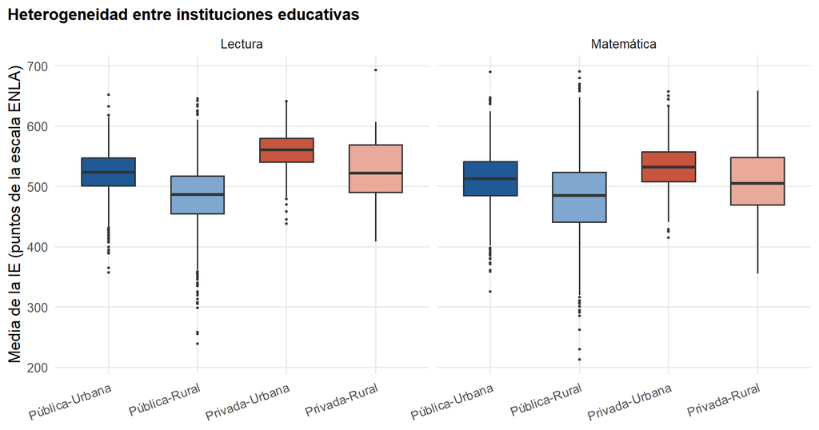

Figura 5: Distribución de las medias de IE (IE con al menos cinco estudiantes evaluados), por combinación gestión-área.

```r
ggplot(ie_m, aes(x = gestion_area, y = m, fill = gestion_area)) +
  geom_boxplot(outlier.size = 0.4, width = 0.6, show.legend = FALSE) +
  facet_wrap(~prueba) +
  scale_fill_manual(values = c("#1F5A96", "#7FA7CF", "#C8553D", "#E9A99B")) +
  labs(title = "Heterogeneidad entre instituciones educativas",
       x = NULL, y = "Media de la IE (puntos de la escala ENLA)") +
  tema + theme(axis.text.x = element_text(angle = 20, hjust = 1))
```

El modelo nulo de dos niveles estimado con *lme4* (Bates et al., 2015), sin ponderar, arrojó una correlación intraclase de 0,28 en lectura y 0,27 en matemática. Entre la cuarta y la tercera parte de la varianza total corresponde a diferencias entre IE, y la dispersión de las medias de IE es amplia dentro de cada combinación de gestión y área (Figura 5).

**Conclusión provisional: la evidencia apoya H4.** Las observaciones no son independientes; tratarlas como tales subestimaría los errores estándar y, en aprendizaje automático, permitiría que estudiantes de una misma IE aparezcan a la vez en entrenamiento y en prueba. La estimación de la correlación intraclase no incorpora los pesos muestrales y debe tomarse como aproximación.

**Ver código**

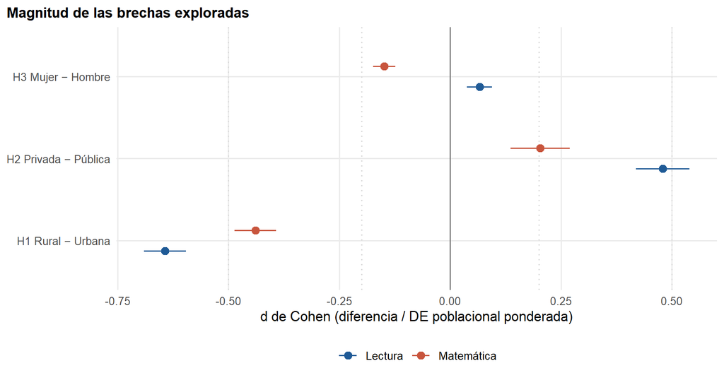

Figura 6: Resumen de tamaños del efecto (d de Cohen con IC 95 % de diseño). Los contrastes se expresan como Rural − Urbana, Privada − Pública y Mujer − Hombre.

```r
bind_rows(cA |> mutate(h = "H1 Rural − Urbana"), cG |> mutate(h = "H2 Privada − Pública"),
          cS |> mutate(h = "H3 Mujer − Hombre")) |>
  distinct(h, prueba, d, d_li, d_ls) |>
  ggplot(aes(x = d, y = h, colour = prueba)) +
  geom_vline(xintercept = 0, colour = "grey50") +
  geom_vline(xintercept = c(-0.5, -0.2, 0.2, 0.5), colour = "grey85", linetype = 3) +
  geom_pointrange(aes(xmin = d_li, xmax = d_ls), position = position_dodge(width = 0.5)) +
  scale_colour_manual(values = pal2, name = NULL) +
  labs(title = "Magnitud de las brechas exploradas",
       x = "d de Cohen (diferencia / DE poblacional ponderada)", y = NULL) + tema
```

# 6 Hallazgos y decisiones para la Unidad II

Las cuatro hipótesis reciben apoyo exploratorio, con magnitudes muy desiguales: la brecha por área es la de mayor tamaño, la de gestión es marcada en lectura y modesta en matemática, y la de sexo es pequeña y cambia de signo según la prueba. Un modelo lineal ponderado con área, gestión y sexo como predictores explica alrededor del 8,6 % de la varianza de lectura y del 3,6 % de la de matemática. Estos valores anticipan una capacidad predictiva limitada si no se incorporan nuevas fuentes de información.

**Variables respuesta.** Para la tarea de regresión se usarán `lect` y `mat`, modeladas por separado. Para la tarea de clasificación se usarán `satisf_lect` y `satisf_mat` (binarias); `nivel_lect` y `nivel_mat` quedan disponibles para modelos ordinales.

**Variables que pasan al modelado.** `area`, `gestion`, `sexo`, `dre` (o `cod_dre`), `n_eval_ie` y, como variables de diseño (no predictores), `id_ie`, `estrato`, `peso_lect` y `peso_mat`. Se recomienda enlazar indicadores distritales del INEI por `ubigeo` para aproximar el nivel socioeconómico, cuya ausencia es la principal amenaza a la validez de las conclusiones.

**Riesgos identificados y tratamiento previsto.**

- *Desbalance de clases.* Solo el 13,7 % de los estudiantes alcanza el nivel satisfactorio en matemática y el 24,9 % en lectura. Se reportarán AUC-PR, sensibilidad y F1 junto con la exactitud, y se evaluarán pesos de clase o ajuste del umbral, siempre dentro de la validación cruzada.
- *Multicolinealidad y celdas escasas.* La asociación entre gestión y área es moderada (V de Cramér = 0,20), insuficiente para producir colinealidad severa, pero la celda Privada-Rural (n = 381) impide estimar con precisión la interacción gestión × área. Se revisarán los factores de inflación de la varianza en los modelos lineales.
- *Fuga de información.* `nivel_*` y `satisf_*` derivan de `lect` y `mat` mediante puntos de corte y no pueden usarse como predictores de la medida, ni viceversa. Tampoco se crearán agregados de IE a partir de los resultados (por ejemplo, la media de la IE). La estandarización (`z_*`) y cualquier imputación o reducción de dimensionalidad se reajustarán dentro de cada pliegue (Kapoor & Narayanan, 2023).
- *Dependencia por conglomerado.* Dada la correlación intraclase cercana a 0,28, la validación cruzada se hará agrupada por `id_ie` y la inferencia se apoyará en modelos multinivel o en errores estándar de diseño.
- *Representatividad.* Los modelos explicativos usarán los factores de expansión; en los modelos predictivos se compararán las métricas con y sin ponderación.

# Declaración de uso de IA generativa

Se utilizó Claude (Anthropic) como asistente en la estructuración del script de preparación en R, el diseño del registro de decisiones y del diccionario, y la redacción preliminar del reporte. Las cifras del documento se calculan por código a partir de la base del MINEDU. Los autores han revisado el código, verificado los resultados frente a la base cruda y asumen la responsabilidad del contenido.

# Referencias

Bates, D., Mächler, M., Bolker, B., & Walker, S. (2015). Fitting Linear Mixed-Effects Models Using lme4. *Journal of Statistical Software*, *67*(1), 1-48. https://doi.org/10.18637/jss.v067.i01

Cohen, J. (1988). *Statistical Power Analysis for the Behavioral Sciences* (2.ª ed.). Lawrence Erlbaum Associates. https://doi.org/10.4324/9780203771587

Kapoor, S., & Narayanan, A. (2023). Leakage and the reproducibility crisis in machine-learning-based science. *Patterns*, *4*(9), 100804. https://doi.org/10.1016/j.patter.2023.100804

Lumley, T. (2004). Analysis of Complex Survey Samples. *Journal of Statistical Software*, *9*(8), 1-19. https://doi.org/10.18637/jss.v009.i08

# Anexo. Entorno de ejecución

```
R version 4.5.2 (2025-10-31 ucrt)
```

```
dplyr      1.2.1
tidyr      1.3.2
ggplot2    4.0.3
survey     4.5
lme4       2.1.0
knitr      1.52
scales     1.4.0
```